# Explore and Summarize Data by Cari Plunkett(Nelson)

# Univariate Plots Section

```
## 'data.frame':    1599 obs. of  12 variables:
##  $ fixed.acidity       : num  7.4 7.8 7.8 11.2 7.4 7.4 7.9 7.3 7.8 7.5 ...
##  $ volatile.acidity    : num  0.7 0.88 0.76 0.28 0.7 0.66 0.6 0.65 0.58 0.5 ...
##  $ citric.acid         : num  0 0 0.04 0.56 0 0 0.06 0 0.02 0.36 ...
##  $ residual.sugar      : num  1.9 2.6 2.3 1.9 1.9 1.8 1.6 1.2 2 6.1 ...
##  $ chlorides           : num  0.076 0.098 0.092 0.075 0.076 0.075 0.069 0.065 0.073 0.071 ...
##  $ free.sulfur.dioxide : num  11 25 15 17 11 13 15 15 9 17 ...
##  $ total.sulfur.dioxide: num  34 67 54 60 34 40 59 21 18 102 ...
##  $ density             : num  0.998 0.997 0.997 0.998 0.998 ...
##  $ pH                  : num  3.51 3.2 3.26 3.16 3.51 3.51 3.3 3.39 3.36 3.35 ...
##  $ sulphates           : num  0.56 0.68 0.65 0.58 0.56 0.56 0.46 0.47 0.57 0.8 ...
##  $ alcohol             : num  9.4 9.8 9.8 9.8 9.4 9.4 9.4 10 9.5 10.5 ...
##  $ quality             : int  5 5 5 6 5 5 5 7 7 5 ...
```

```
##  fixed.acidity   volatile.acidity  citric.acid    residual.sugar
##  Min.   : 4.60   Min.   :0.1200   Min.   :0.000   Min.   : 0.900
##  1st Qu.: 7.10   1st Qu.:0.3900   1st Qu.:0.090   1st Qu.: 1.900
##  Median : 7.90   Median :0.5200   Median :0.260   Median : 2.200
##  Mean   : 8.32   Mean   :0.5278   Mean   :0.271   Mean   : 2.539
##  3rd Qu.: 9.20   3rd Qu.:0.6400   3rd Qu.:0.420   3rd Qu.: 2.600
##  Max.   :15.90   Max.   :1.5800   Max.   :1.000   Max.   :15.500
##    chlorides       free.sulfur.dioxide total.sulfur.dioxide
##  Min.   :0.01200   Min.   : 1.00       Min.   :  6.00
##  1st Qu.:0.07000   1st Qu.: 7.00       1st Qu.: 22.00
##  Median :0.07900   Median :14.00       Median : 38.00
##  Mean   :0.08747   Mean   :15.87       Mean   : 46.47
##  3rd Qu.:0.09000   3rd Qu.:21.00       3rd Qu.: 62.00
##  Max.   :0.61100   Max.   :72.00       Max.   :289.00
##     density             pH          sulphates         alcohol
##  Min.   :0.9901   Min.   :2.740   Min.   :0.3300   Min.   : 8.40
##  1st Qu.:0.9956   1st Qu.:3.210   1st Qu.:0.5500   1st Qu.: 9.50
##  Median :0.9968   Median :3.310   Median :0.6200   Median :10.20
##  Mean   :0.9967   Mean   :3.311   Mean   :0.6581   Mean   :10.42
##  3rd Qu.:0.9978   3rd Qu.:3.400   3rd Qu.:0.7300   3rd Qu.:11.10
##  Max.   :1.0037   Max.   :4.010   Max.   :2.0000   Max.   :14.90
##     quality
##  Min.   :3.000
##  1st Qu.:5.000
##  Median :6.000
##  Mean   :5.636
##  3rd Qu.:6.000
##  Max.   :8.000
```

The red wine data set includes 1599 observations with 12 variables, 13 after I created another variable.

[output not shown]

[output cut: 33 more lines]

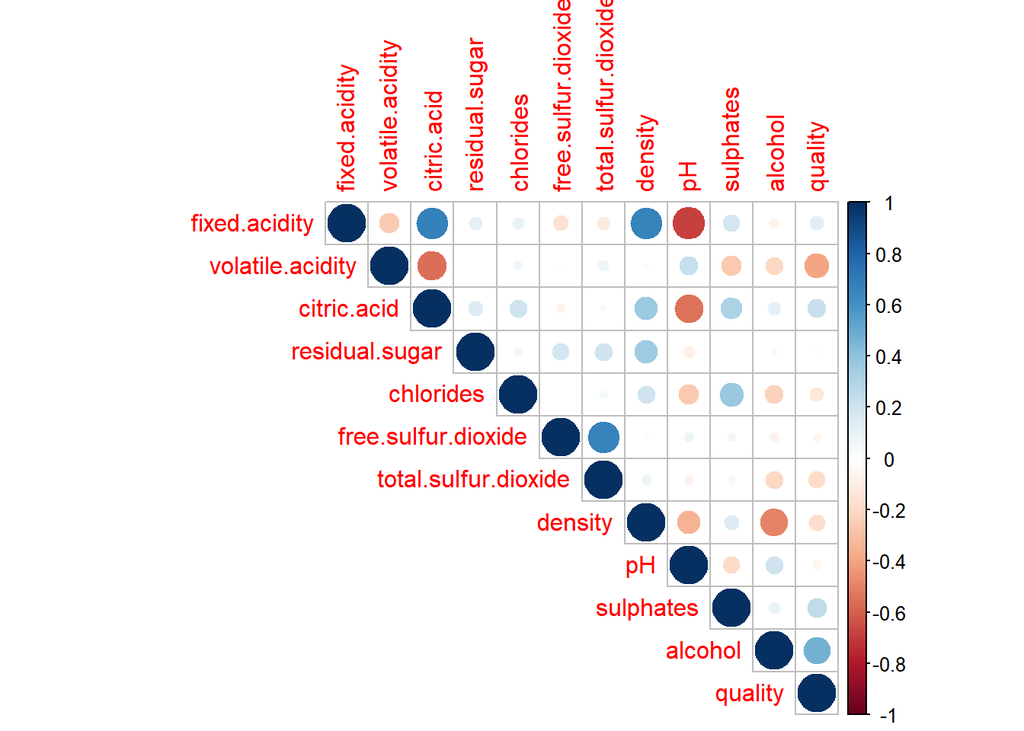

While you will see more specific information later in regards to correlation coefficients for this data set, I wanted to see a correlation matrix of the data first.

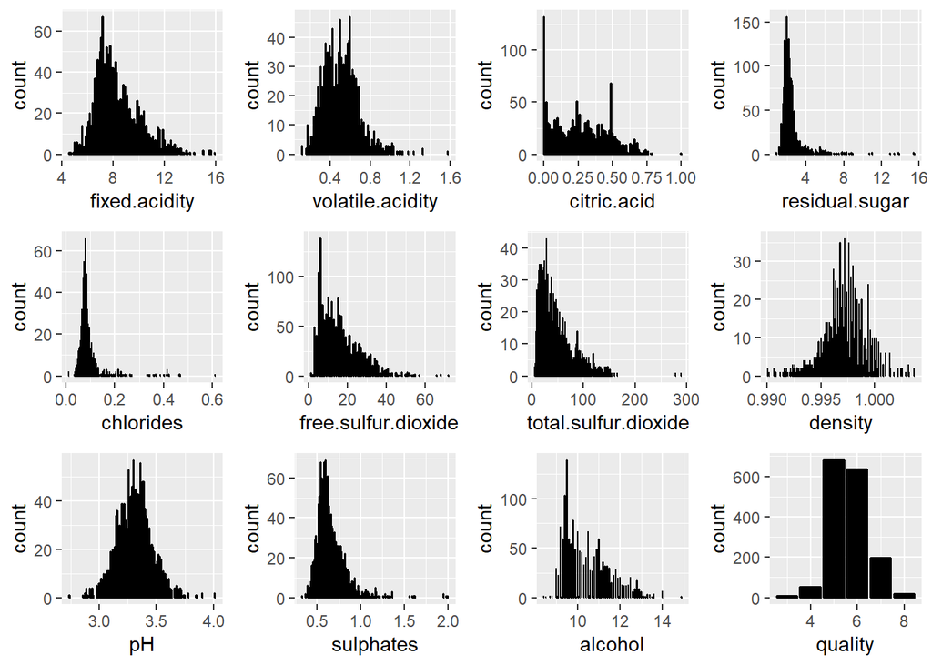

Interpretation of these variables:  
Fixed Acidity - normal distribution  
Volatile Acidity - normal distribution  
Citric Acid - skewed to the right  
Residual Sugar - with possible outliers need to take a closer look  
Chlorides - with possible outliers need to take a closer look  
Free Sulfur Dioxide - skewed to the right  
Total Sulfur Dioxide - skewed to the right  
Density - normal distribution  
pH - normal distribution  
Sulphates - normal distribution with some outliers  
Alcohol - skewed to the right  
Quality - normal distribution

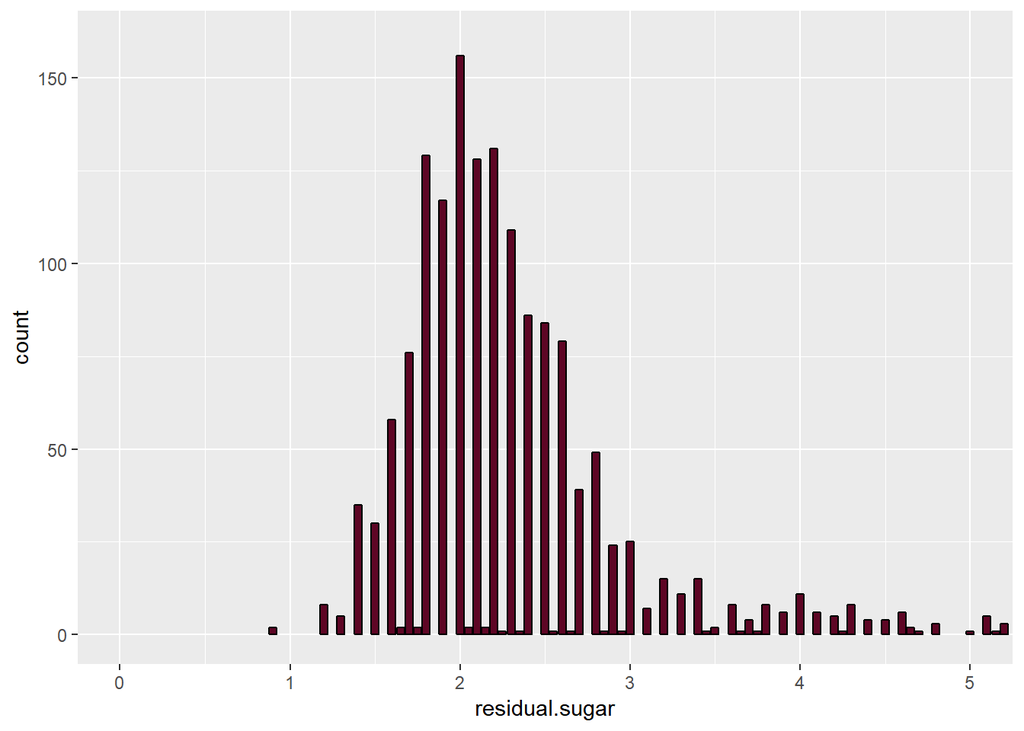

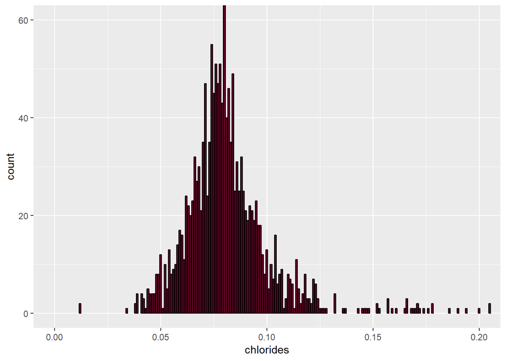

Confirming residual sugar and chlorides have normal distributions.

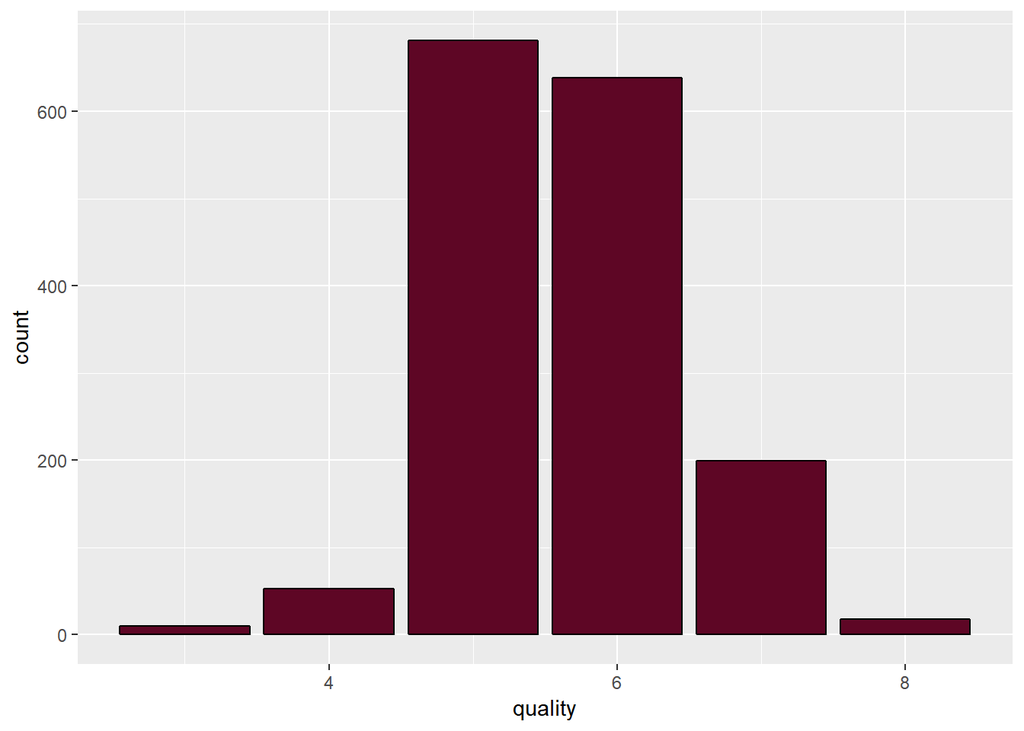

```
##    Min. 1st Qu.  Median    Mean 3rd Qu.    Max.
##   3.000   5.000   6.000   5.636   6.000   8.000
```

A closer look at the quality variable which also confirms it has a normal distribution.

```
##
##   3   4   5   6   7   8
##  10  53 681 638 199  18
```

There are no wines rated less than 3, nor higher than 8.

```
##     low average    high
##      63    1319     217
```

Separated levels of quality into categories even though we are missing the highest and lowest levels in this data.

```
## red$rating: low
##    Min. 1st Qu.  Median    Mean 3rd Qu.    Max.
##    8.40    9.60   10.00   10.22   11.00   13.10
## --------------------------------------------------------
## red$rating: average
##    Min. 1st Qu.  Median    Mean 3rd Qu.    Max.
##    8.40    9.50   10.00   10.25   10.90   14.90
## --------------------------------------------------------
## red$rating: high
##    Min. 1st Qu.  Median    Mean 3rd Qu.    Max.
##    9.20   10.80   11.60   11.52   12.20   14.00
```

Summary of wine rating by alcohol. Notice that, for the most part, the amount of alcohol goes up the highter the rating level.

```
## red$rating: low
##    Min. 1st Qu.  Median    Mean 3rd Qu.    Max.
##  0.2300  0.5650  0.6800  0.7242  0.8825  1.5800
## --------------------------------------------------------
## red$rating: average
##    Min. 1st Qu.  Median    Mean 3rd Qu.    Max.
##  0.1600  0.4100  0.5400  0.5386  0.6400  1.3300
## --------------------------------------------------------
## red$rating: high
##    Min. 1st Qu.  Median    Mean 3rd Qu.    Max.
##  0.1200  0.3000  0.3700  0.4055  0.4900  0.9150
```

Summmary of wine rating by volatile acidity. Here we have the opposite situation, volatile acidity goes down the higher the rating level.

# Univariate Analysis

### What is the structure of your dataset?

There are 1599 observations with 12 variables.

### What is/are the main feature(s) of interest in your dataset?

I am mostly interested in the quality variable and the categories that correlate the most with the quality of the wine.

### What other features in the dataset do you think will help support your investigation into your feature(s) of interest?

I think alcohol will be the most useful, but I am interested in whether quality correlates with residual sugar.

### Did you create any new variables from existing variables in the dataset?

Yes, I created a variable that separates the quality of wine into three categories: low, average, and high.

### Of the features you investigated, were there any unusual distributions? Did you perform any operations on the data to tidy, adjust, or change the form of the data? If so, why did you do this?

I wouldn’t say this is necessarily unusual, but something I was surprised by is that the histograms for residual sugar and chlorides are so similar. This could be due to ignorance on my part, but I’m not sure why this is the case and it may make more sense for those with more knowledge on the subject.

For these two histograms I did set the xlim low enough to exclude outliers. This was to see if both graphs were a normal distribution without the outliers.

I did find it unusual that only wine rated with a quality of 3 to 8 are available in this data. In my opinion, the most interesting variable is quality and it would be more useful to make sure there are at least some wines included with a 1, 2, 9 or 10 rating.

# Bivariate Plots Section

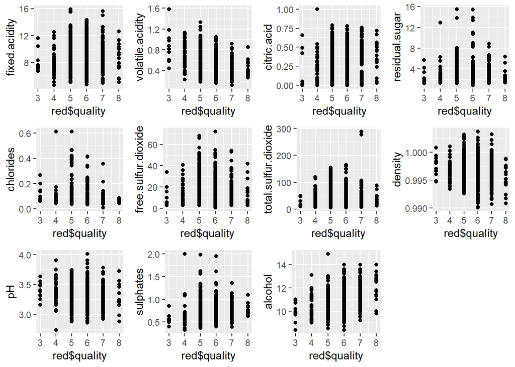

I wanted to get an overall look at how quality relates to every other variable.

```
##
##  Pearson's product-moment correlation
##
## data:  red$quality and red$fixed.acidity
## t = 4.996, df = 1597, p-value = 6.496e-07
## alternative hypothesis: true correlation is not equal to 0
## 95 percent confidence interval:
##  0.07548957 0.17202667
## sample estimates:
##       cor
## 0.1240516
```

```
##
##  Pearson's product-moment correlation
##
## data:  red$quality and red$volatile.acidity
## t = -16.954, df = 1597, p-value < 2.2e-16
## alternative hypothesis: true correlation is not equal to 0
## 95 percent confidence interval:
##  -0.4313210 -0.3482032
## sample estimates:
##        cor
## -0.3905578
```

```
##
##  Pearson's product-moment correlation
##
## data:  red$quality and red$citric.acid
## t = 9.2875, df = 1597, p-value < 2.2e-16
## alternative hypothesis: true correlation is not equal to 0
## 95 percent confidence interval:
##  0.1793415 0.2723711
## sample estimates:
##       cor
## 0.2263725
```

```
##
##  Pearson's product-moment correlation
##
## data:  red$quality and red$residual.sugar
## t = 0.5488, df = 1597, p-value = 0.5832
## alternative hypothesis: true correlation is not equal to 0
## 95 percent confidence interval:
##  -0.03531327  0.06271056
## sample estimates:
##        cor
## 0.01373164
```

```
##
##  Pearson's product-moment correlation
##
## data:  red$quality and red$chlorides
## t = -5.1948, df = 1597, p-value = 2.313e-07
## alternative hypothesis: true correlation is not equal to 0
## 95 percent confidence interval:
##  -0.17681041 -0.08039344
## sample estimates:
##        cor
## -0.1289066
```

```
##
##  Pearson's product-moment correlation
##
## data:  red$quality and red$free.sulfur.dioxide
## t = -2.0269, df = 1597, p-value = 0.04283
## alternative hypothesis: true correlation is not equal to 0
## 95 percent confidence interval:
##  -0.099430290 -0.001638987
## sample estimates:
##         cor
## -0.05065606
```

```
##
##  Pearson's product-moment correlation
##
## data:  red$quality and red$total.sulfur.dioxide
## t = -7.5271, df = 1597, p-value = 8.622e-14
## alternative hypothesis: true correlation is not equal to 0
## 95 percent confidence interval:
##  -0.2320162 -0.1373252
## sample estimates:
##        cor
## -0.1851003
```

```
##
##  Pearson's product-moment correlation
##
## data:  red$quality and red$density
## t = -7.0997, df = 1597, p-value = 1.875e-12
## alternative hypothesis: true correlation is not equal to 0
## 95 percent confidence interval:
##  -0.2220365 -0.1269870
## sample estimates:
##        cor
## -0.1749192
```

```
##
##  Pearson's product-moment correlation
##
## data:  red$quality and red$pH
## t = -2.3109, df = 1597, p-value = 0.02096
## alternative hypothesis: true correlation is not equal to 0
## 95 percent confidence interval:
##  -0.106451268 -0.008734972
## sample estimates:
##         cor
## -0.05773139
```

```
##
##  Pearson's product-moment correlation
##
## data:  red$quality and red$sulphates
## t = 10.38, df = 1597, p-value < 2.2e-16
## alternative hypothesis: true correlation is not equal to 0
## 95 percent confidence interval:
##  0.2049011 0.2967610
## sample estimates:
##       cor
## 0.2513971
```

```
##
##  Pearson's product-moment correlation
##
## data:  red$quality and red$alcohol
## t = 21.639, df = 1597, p-value < 2.2e-16
## alternative hypothesis: true correlation is not equal to 0
## 95 percent confidence interval:
##  0.4373540 0.5132081
## sample estimates:
##       cor
## 0.4761663
```

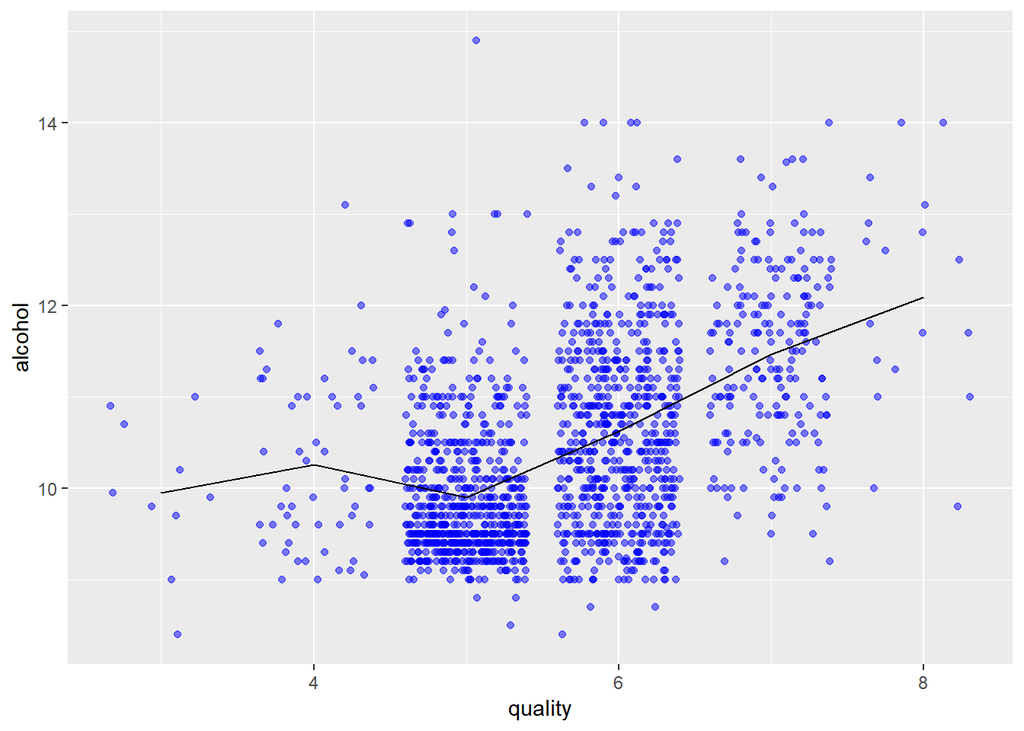

I wanted to see how alcohol and quality directly relate to eachother. Although there were suggestions that from previous analysis that they are positively correlated, this is confirmation that they have a positive correlation.

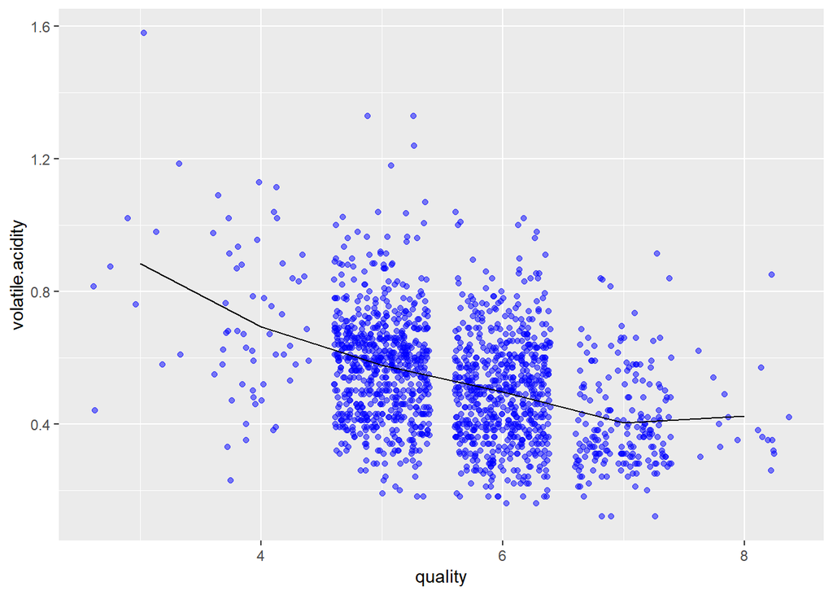

I thought that there seemed to be a negative correlation, and this graph confirms that this is the relationship between these variables.

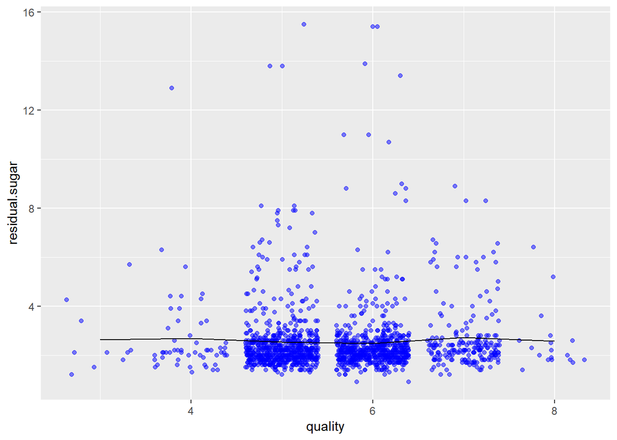

We can see here with this flat line overlapping the scatter plot how little of a relationship residual sugar and quality of wine have with eachother.

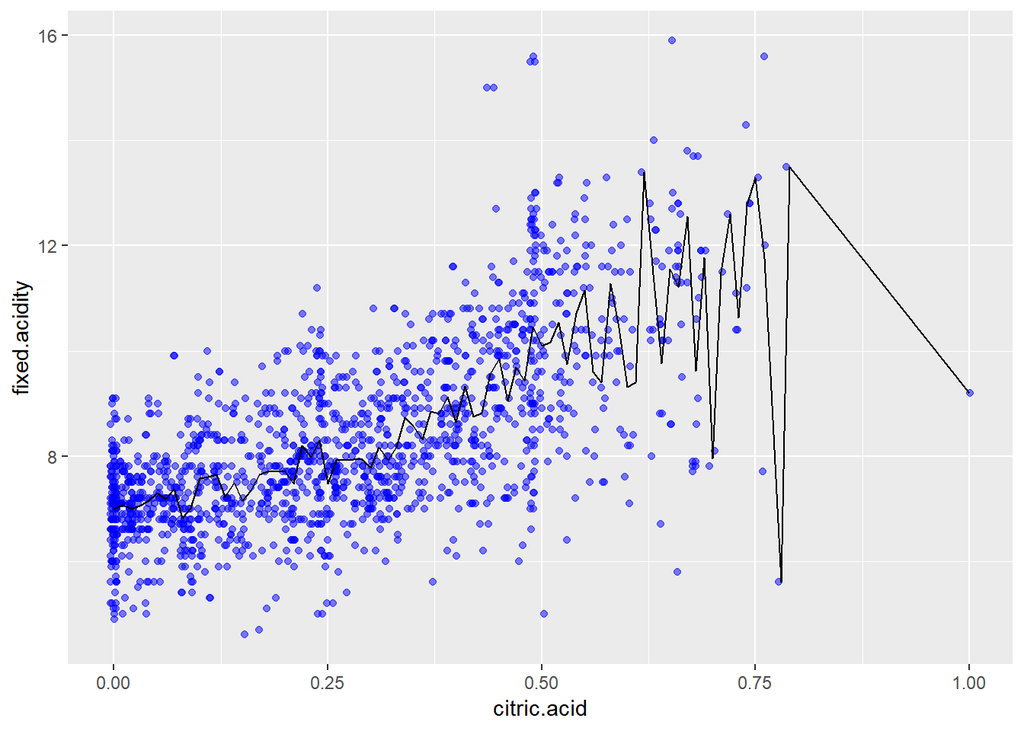

Because of the correlation matrix we saw early on, I wanted to look into the relationship between fixed acidity and citric acid. This is more confirmation of their positive correlation.

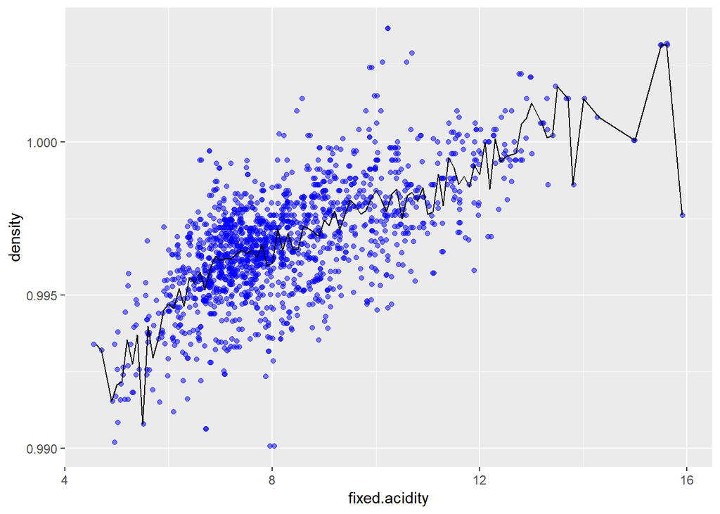

I also wanted to see the relationship between fixed acidity and density due to the correlation matrix and their positive correlation.

# Bivariate Analysis

### Did you observe any interesting relationships between the other features (not the main feature(s) of interest)?

Yes, that volatile acidity is moderately negatively correlated with wine quality.

### What was the strongest relationship you found?

Alcohol was the variable with the highest correlation with quality, and a correlation coefficient of 0.48.

# Multivariate Plots Section

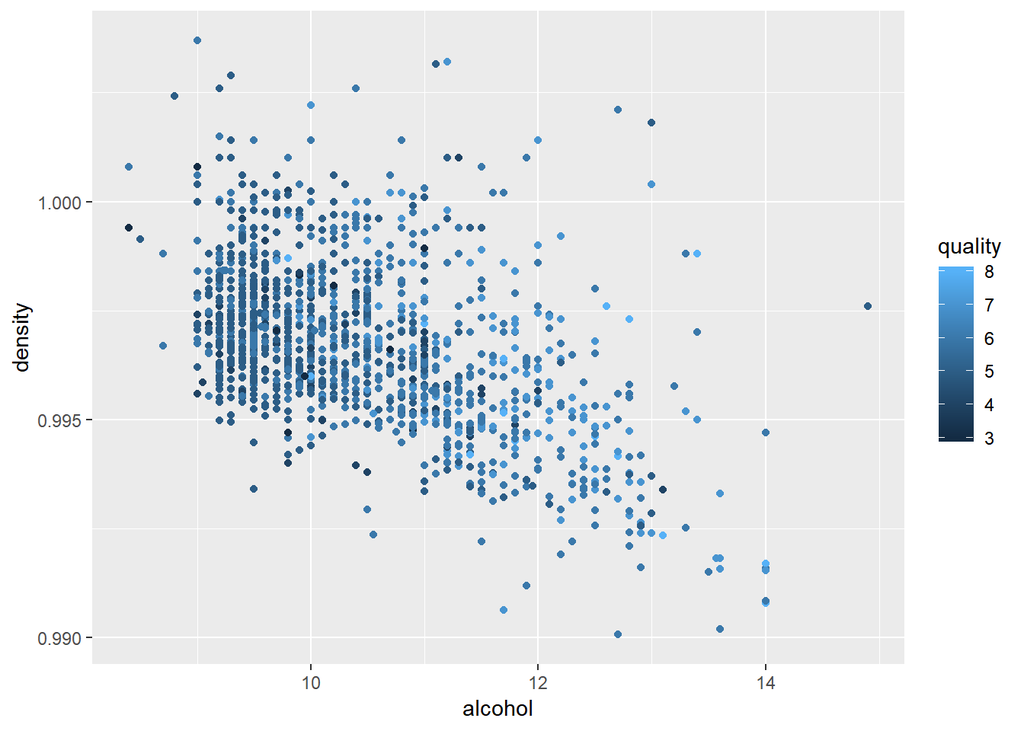

Density may be positively correlated with fixed acidity, but it doesn’t appear to affect quality.

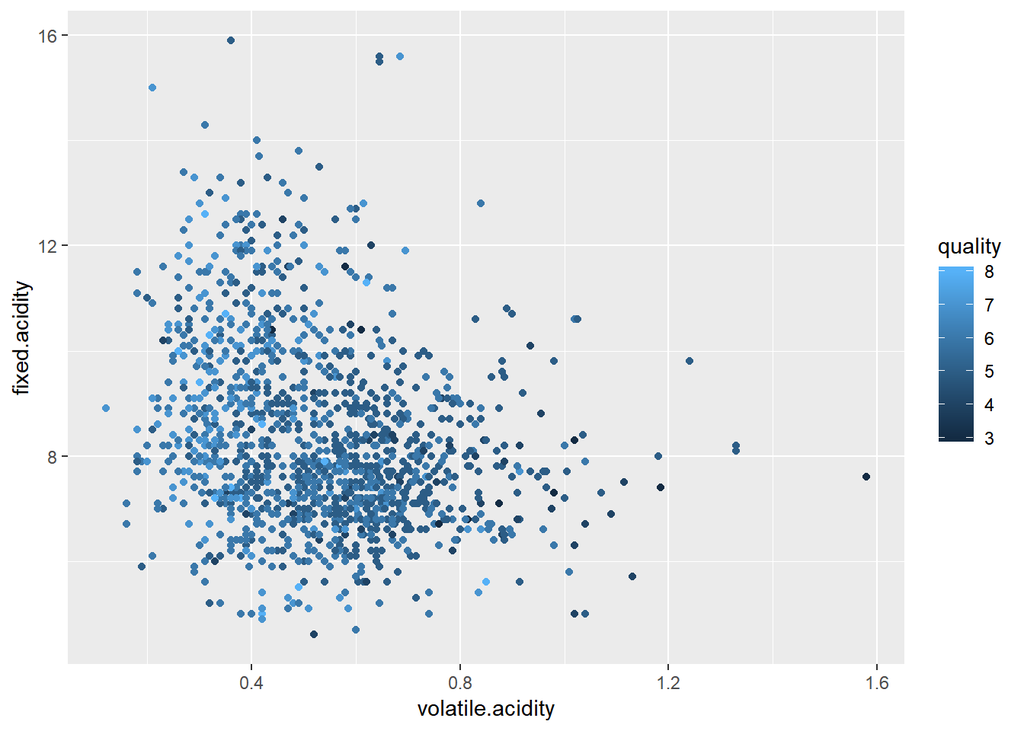

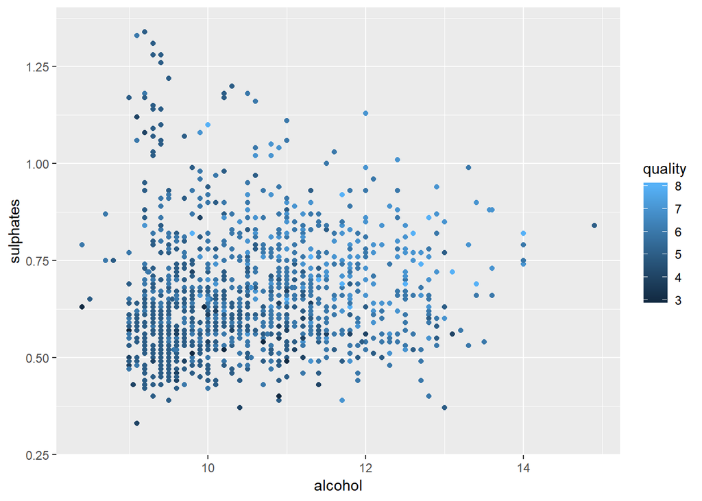

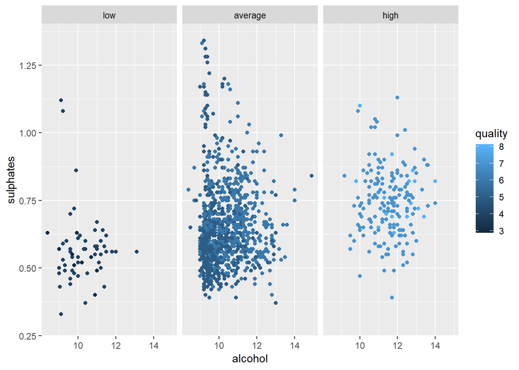

High alcohol and high sulphates seem to result in a higher quality of wine.

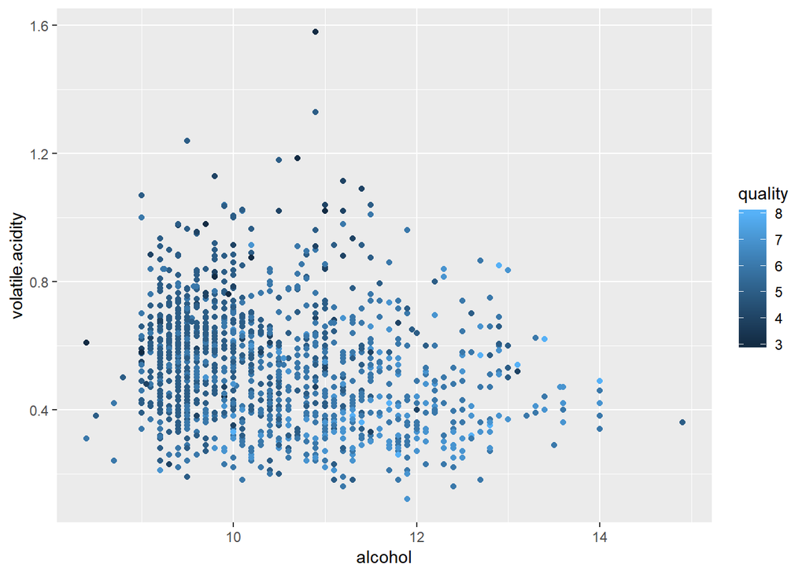

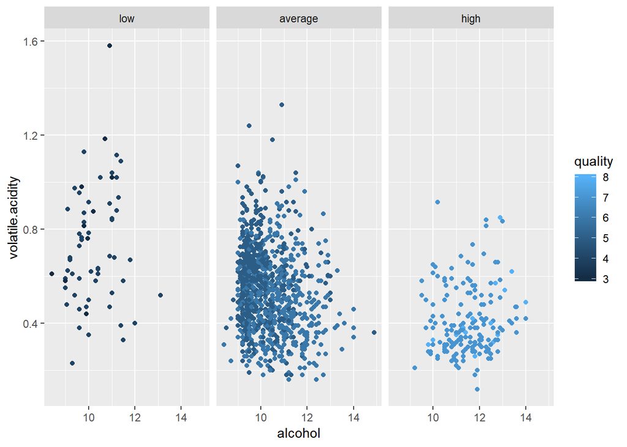

However, higher alcohol and less volatile acidity result in better quality wine. This seems to be the two most important factors when it comes to the quality of red wine.

# Multivariate Analysis

### Talk about some of the relationships you observed in this part of the investigation. Were there features that strengthened each other in terms of looking at your feature(s) of interest?

High alcohol and low volatile acidity seem to result in a higher quality wine.

### Were there any interesting or surprising interactions between features?

It was surprising that high alcohol and high sulphates result in higher quality wine.

# Final Plots and Summary

### Plot One

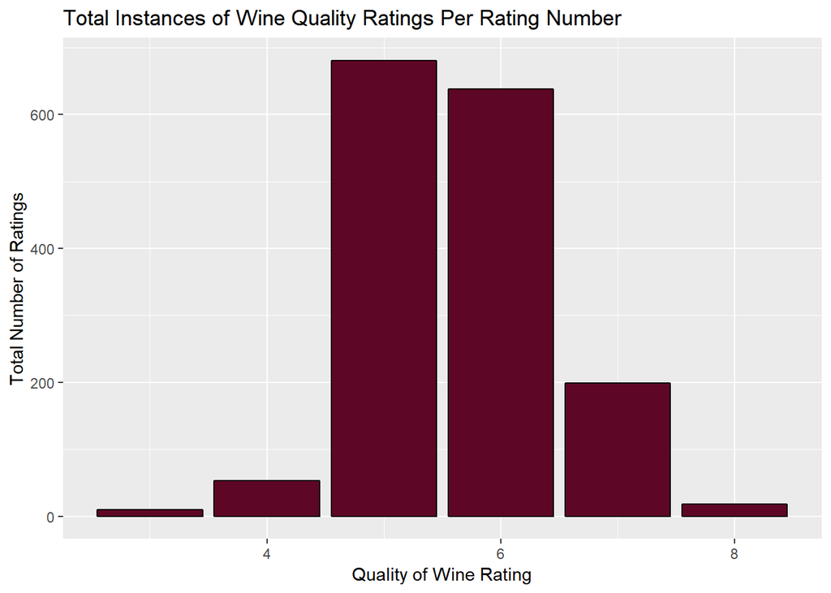

### Description One

This graph stood out to me not only because I expected quality to be the most interesting variable, but because some rating numbers had no data whatsoever.

### Plot Two

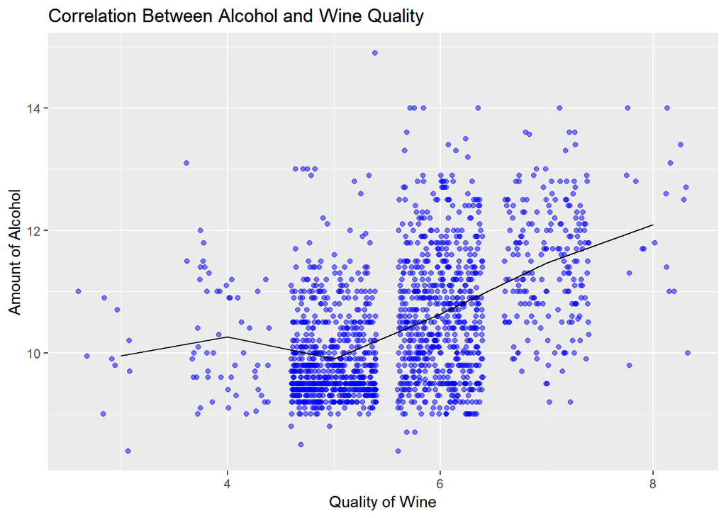

### Description Two

This graph was confirmation that the amount of alcohol in red wine seems to positively correlate with wine quality. I used jitter to adjust overplotting and geom_line to plot a line showing the mean on top of the scatter plot.

### Plot Three

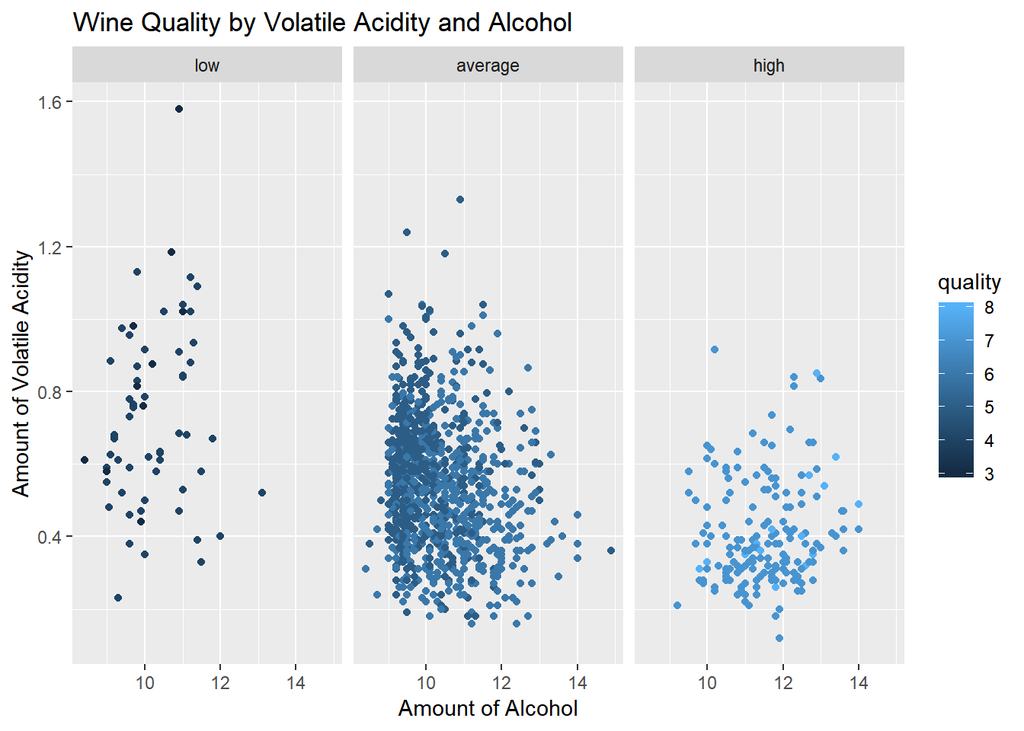

[output not shown]